# Understanding mixed effects models through simulating data

Extended Example

Lisa DeBruine and Dale Barr

```r
library(lmerTest)    # for mixed effects models
library(tidyverse)   # for data wrangling and visualisation
library(faux)        # devtools::install_github("debruine/faux")
library(broom.mixed) # for extracting data from mixed effects models

set.seed(90210)
```

### Set Study Parameters

Set up your study parameters. In this example, 50 subjects will respond twice (pre- and post-intervention) to 50 items; 25 items in each of 2 conditions. In this example, `time` is a within-subject and within-item factor and `condition` is a within-subject and between-item factor.

```r
nsubj  <- 50 # number of subjects per between-subject cell
nitem  <- 25 # number of items per between-item cell
```

### Fixed effects

We will predict that in a pre-intervention condition, we will see the same effects as in the first example: an 80ms difference between classification of emotions in ingroup and outgroup faces. We have an intervention that we predict will eliminate this difference. We’ve also observed that people get about 100ms faster the second time they do the task, so the mean RT in the post-intervention condition is 700ms, making the overal mean 750ms.

```r
mu       <- 750 # grand mean
eff_cond <-  40 # main effect of condition
eff_time <- -100 # main effect of time
eff_ct   <- -80 # interaction between condition and time
```

### Random effects

```r
# items
iri_sd   <- 80 # by-item random intercept sd
irs_t_sd <- 80 # by-item random slope for time
icor     <- .2 # correlation between intercept and slope

# subjects
sri_sd    <- 100 # by-subject random intercept sd
srs_c_sd  <- 40  # by-subject random slope sd for condition
srs_t_sd  <- 80  # by-subject random slope sd for time
srs_ct_sd <- 80  # by-subject random slope sd for conditon*time
# correlations between intercept and slopes
scor      <- c(.3, .3, .3,
                   .1, .1,
                       .1)

# error
err_sd <- 200 # residual sd
```

### Simulate Items

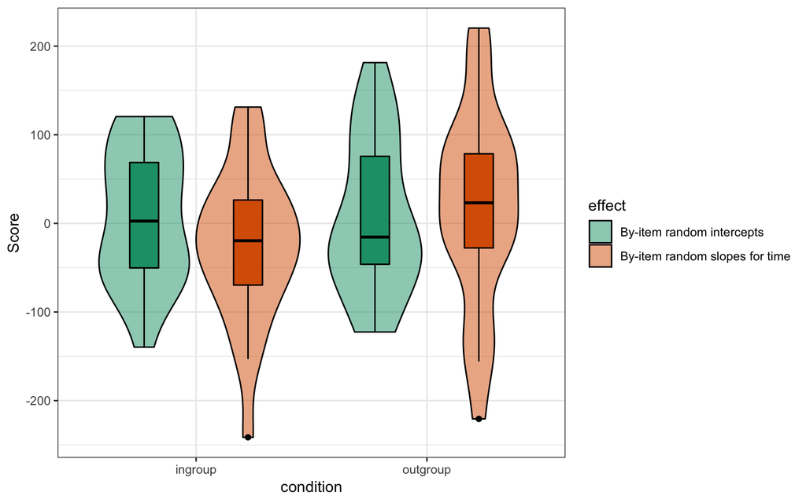

The distribution of random effects for ingroup and outgroup faces.

```r
items <- faux::sim_design(
  within = list(effect = c(iri = "By-item random intercepts",
                           irs.t = "By-item random slopes for time")),
  between = list(condition = c("ingroup", "outgroup")),
  n = nitem,
  sd = list(ingroup = c(iri_sd, irs_t_sd),
            outgroup = c(iri_sd, irs_t_sd)),
  r = icor,
  id = "item_id",
  plot = FALSE
)

plot_design(items)
```

### Simulate Subjects

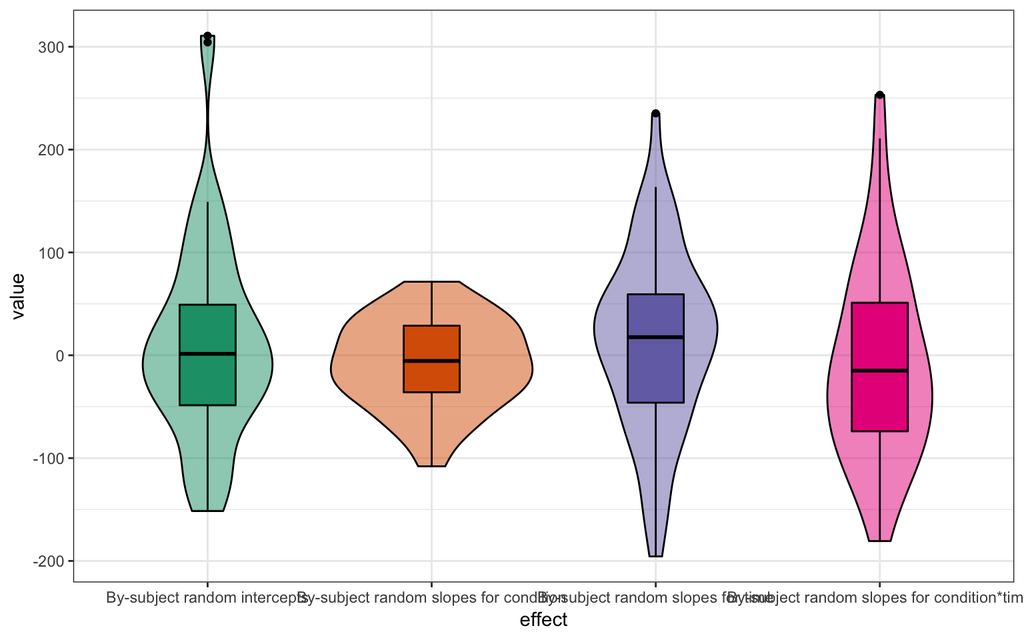

The distribution of random effects for subjects

```r
subjects <- faux::sim_design(
  within = list(effect = c(sri = "By-subject random intercepts",
                           srs.c = "By-subject random slopes for condition",
                           srs.t = "By-subject random slopes for time",
                           srs.ct = "By-subject random slopes for condition*time")),
  n = nsubj,
  sd = c(sri = sri_sd,
         srs.c = srs_c_sd,
         srs.t = srs_t_sd,
         srs.ct = srs_ct_sd),
  r = scor,
  dv = "value",
  id = "subj_id",
  plot = FALSE
)

plot_design(subjects)
```

### Simulate Trials

Since all subjects respond to all items, we can set up a table of trials by crossing the subject IDs with the item IDs. Each trial has random error associated; we simulate this from a normal distribution with a mean of 0 and SD of `err_sd`.

```r
dat_sim <- crossing(subj_id = subjects$subj_id,
                    item_id = items$item_id,
                    time = factor(c("pre", "post"), levels = c("pre", "post"))) %>%
  inner_join(subjects, "subj_id") %>%
  inner_join(items, "item_id") %>%
  mutate(time.e = recode(time, "pre" = -0.5, "post" = 0.5),
         cond.e = recode(condition, "ingroup" = -0.5, "outgroup" = +0.5),
         trial_i    = mu + iri +  sri,
         trial_cond = eff_cond + srs.c,
         trial_time = eff_time + irs.t + srs.t,
         trial_ct   = eff_ct + srs.ct,
         err = rnorm(nrow(.), mean = 0, sd = err_sd),
         Y = trial_i + (trial_cond*cond.e) + (trial_time*time.e) +
           (trial_ct*cond.e*time.e) + err)
```

Plot your data to double-check it looks like you expect.

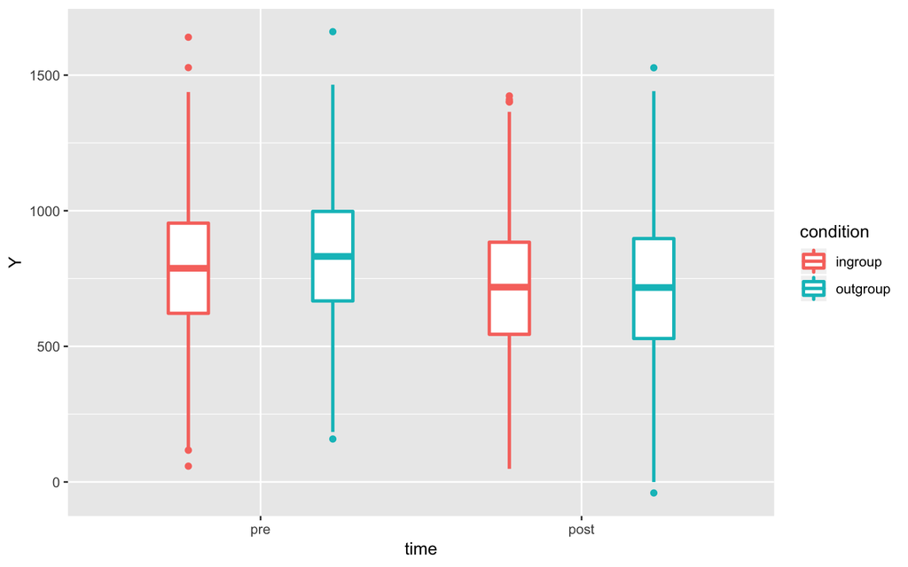

```r
ggplot(dat_sim, aes(time, Y, color = condition)) +
  geom_boxplot(width = 0.25, size = 1,
               position = position_dodge(width = 0.9))
```

### Analyse Data

```r
mod_sim <- lmer(Y ~ 1 + cond.e*time.e +
                  (1 + time.e | item_id) +
                  (1 + cond.e*time.e | subj_id),
                data = dat_sim, REML = TRUE)
```

```r
broom.mixed::tidy(mod_sim) %>%
  mutate(sim_params = c(mu, eff_cond, eff_time, eff_ct, iri_sd, irs_t_sd, icor,
                        sri_sd, srs_c_sd, srs_t_sd, srs_ct_sd, scor, err_sd)) %>%
  select(effect, group, term, sim_params, everything()) %>%
  knitr::kable(digits = 3)
```

| effect | group | term | sim_params | estimate | std.error | statistic | df | p.value |
| --- | --- | --- | --- | --- | --- | --- | --- | --- |
| fixed | NA | (Intercept) | 750.0 | 764.070 | 17.784 | 42.964 | 89.787 | 0.000 |
| fixed | NA | cond.e | 40.0 | 22.671 | 23.698 | 0.957 | 52.571 | 0.343 |
| fixed | NA | time.e | -100.0 | -91.104 | 20.479 | -4.449 | 80.705 | 0.000 |
| fixed | NA | cond.e:time.e | -80.0 | -41.864 | 35.414 | -1.182 | 60.838 | 0.242 |
| ran_pars | item_id | sd__(Intercept) | 80.0 | 79.053 | NA | NA | NA | NA |
| ran_pars | item_id | sd__time.e | 80.0 | 108.637 | NA | NA | NA | NA |
| ran_pars | item_id | cor__(Intercept).time.e | 0.2 | 0.208 | NA | NA | NA | NA |
| ran_pars | subj_id | sd__(Intercept) | 100.0 | 95.735 | NA | NA | NA | NA |
| ran_pars | subj_id | sd__cond.e | 40.0 | 38.553 | NA | NA | NA | NA |
| ran_pars | subj_id | sd__time.e | 80.0 | 87.021 | NA | NA | NA | NA |
| ran_pars | subj_id | sd__cond.e:time.e | 80.0 | 95.493 | NA | NA | NA | NA |
| ran_pars | subj_id | cor__(Intercept).cond.e | 0.3 | 0.174 | NA | NA | NA | NA |
| ran_pars | subj_id | cor__(Intercept).time.e | 0.3 | 0.389 | NA | NA | NA | NA |
| ran_pars | subj_id | cor__(Intercept).cond.e:time.e | 0.3 | 0.271 | NA | NA | NA | NA |
| ran_pars | subj_id | cor__cond.e.time.e | 0.1 | 0.155 | NA | NA | NA | NA |
| ran_pars | subj_id | cor__cond.e.cond.e:time.e | 0.1 | -0.118 | NA | NA | NA | NA |
| ran_pars | subj_id | cor__time.e.cond.e:time.e | 0.1 | 0.179 | NA | NA | NA | NA |
| ran_pars | Residual | sd__Observation | 200.0 | 199.683 | NA | NA | NA | NA |

```r
summary(mod_sim, corr = FALSE)
```

```
## Linear mixed model fit by REML. t-tests use Satterthwaite's method [
## lmerModLmerTest]
## Formula: Y ~ 1 + cond.e * time.e + (1 + time.e | item_id) + (1 + cond.e *
##     time.e | subj_id)
##    Data: dat_sim
##
## REML criterion at convergence: 67674.3
##
## Scaled residuals:
##     Min      1Q  Median      3Q     Max
## -3.5476 -0.6532 -0.0006  0.6511  3.4204
##
## Random effects:
##  Groups   Name          Variance Std.Dev. Corr
##  item_id  (Intercept)    6249     79.05
##           time.e        11802    108.64   0.21
##  subj_id  (Intercept)    9165     95.74
##           cond.e         1486     38.55    0.17
##           time.e         7573     87.02    0.39  0.16
##           cond.e:time.e  9119     95.49    0.27 -0.12  0.18
##  Residual               39873    199.68
## Number of obs: 5000, groups:  item_id, 50; subj_id, 50
##
## Fixed effects:
##               Estimate Std. Error     df t value Pr(>|t|)
## (Intercept)     764.07      17.78  89.79  42.964  < 2e-16 ***
## cond.e           22.67      23.70  52.57   0.957    0.343
## time.e          -91.10      20.48  80.71  -4.449 2.74e-05 ***
## cond.e:time.e   -41.86      35.41  60.84  -1.182    0.242
## ---
## Signif. codes:  0 '***' 0.001 '**' 0.01 '*' 0.05 '.' 0.1 ' ' 1
## convergence code: 0
## Model failed to converge with max|grad| = 0.0389173 (tol = 0.002, component 1)
```

## Power

```r
my_sim_func <- function(nsubj     = 50,   # N subjects / between-subject cell
                        nitem     = 25,   # N items / between-item cell
                        mu        = 750,  # grand mean
                        eff_cond  =  40,  # main effect of condition
                        eff_time  = -100, # main effect of time
                        eff_ct    = -80,  # interaction between condition and time
                        iri_sd    = 80,   # by-item random intercept sd
                        irs_t_sd  = 80,   # by-item random slope for time
                        icor      = .2,   # item ranef cors
                        sri_sd    = 100,  # by-subject random intercept sd
                        srs_c_sd  = 40,   # by-subject random slope sd for condition
                        srs_t_sd  = 80,   # by-subject random slope sd for time
                        srs_ct_sd = 80,   # by-subject random slope sd for conditon*time
                        scor      = c(.3, .3, .3, .1, .1, .1), # subject ranef cors
                        err_sd    = 200   # residual sd
  ) {
  # simulate items
  items <- faux::sim_design(
    within = list(effect = c(iri = "By-item random intercepts",
                             irs.t = "By-item random slopes for time")),
    between = list(condition = c("ingroup", "outgroup")),
    n = nitem,
    sd = list(ingroup = c(iri_sd, irs_t_sd),
              outgroup = c(iri_sd, irs_t_sd)),
    r = icor,
    id = "item_id",
    plot = FALSE
  )

  # simulate subjects
  subjects <- faux::sim_design(
    within = list(effect = c(sri = "By-subject random intercepts",
                             srs.c = "By-subject random slopes for condition",
                             srs.t = "By-subject random slopes for time",
                             srs.ct = "By-subject random slopes for condition*time")),
    n = nsubj,
    sd = c(sri = sri_sd,
           srs.c = srs_c_sd,
           srs.t = srs_t_sd,
           srs.ct = srs_ct_sd),
    r = scor,
    dv = "value",
    id = "subj_id",
    plot = FALSE
  )

  # simulate trials
  dat_sim <- crossing(subj_id = subjects$subj_id,
                      item_id = items$item_id,
                      time = factor(c("pre", "post"), levels = c("pre", "post"))) %>%
    inner_join(subjects, "subj_id") %>%
    inner_join(items, "item_id") %>%
    mutate(time.e = recode(time, "pre" = -0.5, "post" = 0.5),
           cond.e = recode(condition, "ingroup" = -0.5, "outgroup" = +0.5),
           trial_i    = mu + iri +  sri,
           trial_cond = eff_cond + srs.c,
           trial_time = eff_time + irs.t + srs.t,
           trial_ct   = eff_ct + srs.ct,
           err = rnorm(nrow(.), mean = 0, sd = err_sd),
           Y = trial_i + (trial_cond*cond.e) + (trial_time*time.e) +
             (trial_ct*cond.e*time.e) + err)

  mod_sim <- lmer(Y ~ 1 + cond.e*time.e +
                    (1 + time.e | item_id) +
                    (1 + cond.e*time.e | subj_id),
                  data = dat_sim, REML = TRUE)

  broom.mixed::tidy(mod_sim)
}
```

Run the function once with default parameters.

```r
my_sim_func() %>% knitr::kable(digits = 3)
```

| effect | group | term | estimate | std.error | statistic | df | p.value |
| --- | --- | --- | --- | --- | --- | --- | --- |
| fixed | NA | (Intercept) | 742.524 | 20.108 | 36.927 | 85.509 | 0.000 |
| fixed | NA | cond.e | -25.425 | 24.138 | -1.053 | 50.557 | 0.297 |
| fixed | NA | time.e | -109.586 | 16.026 | -6.838 | 74.158 | 0.000 |
| fixed | NA | cond.e:time.e | -87.196 | 24.709 | -3.529 | 62.918 | 0.001 |
| ran_pars | item_id | sd__(Intercept) | 81.729 | NA | NA | NA | NA |
| ran_pars | item_id | sd__time.e | 64.314 | NA | NA | NA | NA |
| ran_pars | item_id | cor__(Intercept).time.e | 0.450 | NA | NA | NA | NA |
| ran_pars | subj_id | sd__(Intercept) | 114.658 | NA | NA | NA | NA |
| ran_pars | subj_id | sd__cond.e | 29.208 | NA | NA | NA | NA |
| ran_pars | subj_id | sd__time.e | 84.538 | NA | NA | NA | NA |
| ran_pars | subj_id | sd__cond.e:time.e | 88.004 | NA | NA | NA | NA |
| ran_pars | subj_id | cor__(Intercept).cond.e | 0.076 | NA | NA | NA | NA |
| ran_pars | subj_id | cor__(Intercept).time.e | 0.189 | NA | NA | NA | NA |
| ran_pars | subj_id | cor__(Intercept).cond.e:time.e | 0.102 | NA | NA | NA | NA |
| ran_pars | subj_id | cor__cond.e.time.e | -0.126 | NA | NA | NA | NA |
| ran_pars | subj_id | cor__cond.e.cond.e:time.e | -0.221 | NA | NA | NA | NA |
| ran_pars | subj_id | cor__time.e.cond.e:time.e | 0.347 | NA | NA | NA | NA |
| ran_pars | Residual | sd__Observation | 197.434 | NA | NA | NA | NA |

You can use the `purrr::map_df` function to run the simulation repeatedly and save the results to a data table. This will take a while, so test using just a few reps first, then make sure you save the full results to a CSV file so you can set this code chunk to not run (`eval = FALSE` in the chunk header) and load from the saved data for the rest of your script in the future.

```r
reps <- 100
sims <- purrr::map_df(1:reps, ~my_sim_func())
write_csv(sims, "ext_sims.csv")
```

```r
sims <- read_csv("ext_sims.csv")
```

You can use these data to calculate power for each fixed effect or plot the distribution of your fixed or random effects.

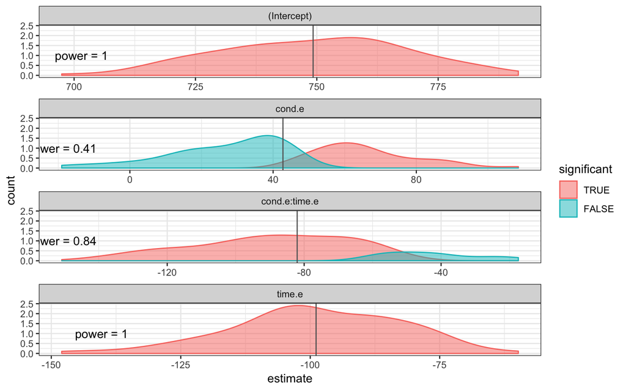

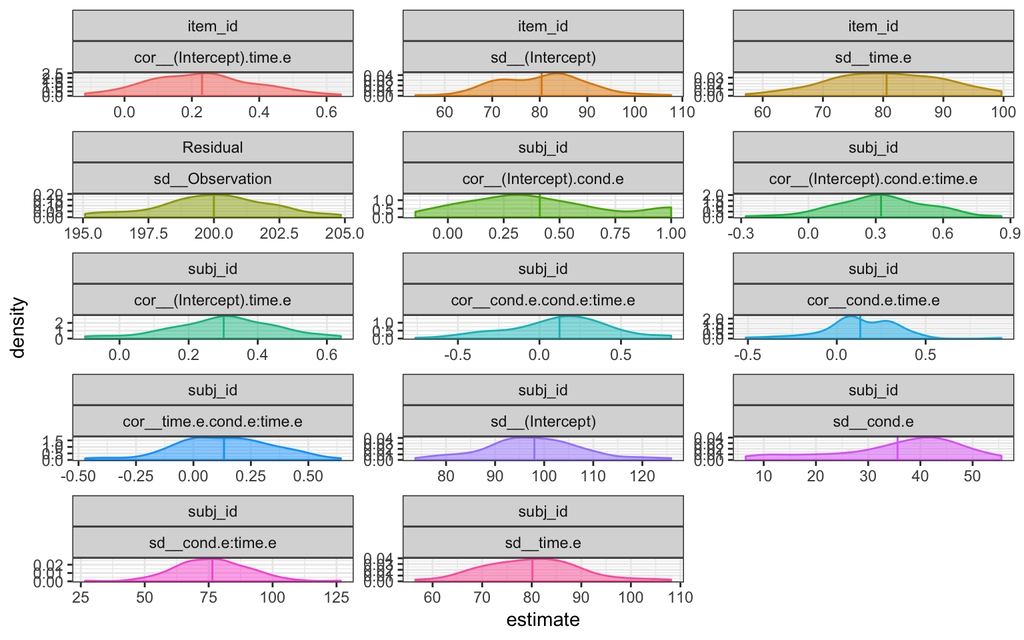